# 肿瘤随访数据生存分析建模报告

陈逸萧

2026-07-17

# R语言临床生存分析报告

本文档基于 R Markdown 编写，可一键渲染生成 HTML、PDF 标准化分析报告。 文档整合研究背景文字说明、数据处理代码、统计输出与可视化图表，实现分析流程全可复现。

点击上方 **Knit** 按钮即可输出完整报告，文档会同时展示代码、统计结果与绘图。 下方为本项目依赖包：

```r
library(survival)
library(tidyverse)
library(survminer)
library(broom)
```

# 1 数据准备

使用survival包内置lung肺癌随访数据，共228例晚期肺癌患者，探究性别、年龄、体能评分等对生存预后的影响。

## 1.1 数据集变量介绍

inst，机构代码 (Institution code) 表示患者所在的治疗中心编号。通常作为随机效应或控制变量，但在本小样本分析中常被忽略。

time，生存时间 (Survival time) 目标变量之一。记录从入组到死亡或最后一次随访的天数。单位：天 (Days)

status，生存状态 (Censoring status) 目标变量之二。指示观察结束时患者的状态。 1 = 删失 (Censored): 患者仍存活或失访 2 = 死亡 (Dead): 事件发生

age，年龄 (Age in years)。单位：岁 (Years)

sex，性别。1 = 男 (Male)，2 = 女 (Female)

ph.ecog，ECOG 体力评分 (ECOG performance score) 关键预测因子。评估患者日常活动能力，分数越高身体状况越差。 0: 正常活动 1: 轻微症状，能从事轻体力活动 2: 白天卧床<50% 3: 白天卧床>50% 4: 完全卧床 5: 死亡

ph.karno，医生评分的 Karnofsky 评分 (Karnofsky score rated by physician)，评估患者功能状态的百分制评分。 分数越高越好（与 ECOG 相反）。范围：0-100 (100=完全健康)

pat.karno，患者自评的 Karnofsky 评分 (Karnofsky score rated by patient)，患者对自己身体状况的主观评分。 常与医生评分对比，分析主观感知对预后的影响。范围：0-100

eal.cal，每日卡路里摄入量 (Calories consumed at meals) 营养状况指标。营养不良是癌症患者预后不良的重要标志。单位：千卡/天 (kcal/day)

wt.loss，体重丢失 (Weight loss in last 6 months) 过去 6 个月内体重下降的磅数。单位：磅 (lbs)。 负值 = 增重，正值 = 减重

## 1.2 原始数据载入

```r
df_raw <- lung
```

## 1.3 分步数据清洗、变量重编码

### 1.3.1 inst列

inst为标识性变量Identifier，它本身没有直接的临床预测意义，仅确认有无数据丢失并检查分布。大样本中该项或许存在一定相关性（不同医疗机构的医疗水平不同，对患者预后有影响），但此项目不作考虑。 经确认，缺失1项，分布无明显失衡，决策：直接删除。

```r
sum(is.na(df_raw$inst))
```

```
## [1] 1
```

```r
df <- df_raw %>%
  drop_na(inst)
table(df$inst) #查看分布
```

```
##
##  1  2  3  4  5  6  7 10 11 12 13 15 16 21 22 26 32 33
## 36  5 19  4  9 14  8  4 18 23 20  6 16 13 17  6  7  2
```

### 1.3.2 time列

time作为生存分析核心目标变量，如有缺失一般直接删除，避免中位数填充（扭曲KM曲线）或均值填充（引入巨大噪声）。 time列变量名容易与R内置“时间”等变量冲突，将其改为survival_days。

```r
sum(is.na(df$time)) #查看缺失值
```

```
## [1] 0
```

```r
sum(df$time <= 0) #查看小于等于0的异常值
```

```
## [1] 0
```

```r
summary(df$time) #查看描述性统计，排除极大极小值
```

```
##    Min. 1st Qu.  Median    Mean 3rd Qu.    Max.
##     5.0   166.5   252.0   305.1   399.0  1022.0
```

```r
df <- df %>%
  rename(survival_days = time) %>%
  drop_na(survival_days) %>%
  filter(survival_days > 0)
```

### 1.3.3 status列

同survival_days，对于终点事件（Endpoint）缺失的数据，唯一的科学处理方法是剔除（Exclusion），并在报告中说明剔除比例。 原始数据为1/2，考虑改为0/1方便建模。

```r
df <- df %>%
  drop_na(status) %>%
  mutate(status = status - 1)
unique(df$status) #检验是否仅为0/1，不存在其他异常值
```

```
## [1] 1 0
```

### 1.3.4 age列

实际无缺失值，如有考虑用中位数填补

```r
sum(is.na(df$age))
```

```
## [1] 0
```

```r
summary(df$age)
```

```
##    Min. 1st Qu.  Median    Mean 3rd Qu.    Max.
##   39.00   56.00   63.00   62.42   69.00   82.00
```

### 1.3.5 sex列

实际无缺失值，如有考虑用众数填补（较少）或增设第三类Unknown（较多） 原始数据为1/2，考虑改为0/1方便建模。

```r
sum(is.na(df$sex))
```

```
## [1] 0
```

```r
df <- df %>%
  mutate(sex = sex - 1)
unique(df$sex)
```

```
## [1] 0 1
```

### 1.3.6 ph.ecog列

有一个缺失值，用众数填充

```r
sum(is.na(df$ph.ecog))
```

```
## [1] 1
```

```r
unique(df$ph.ecog)
```

```
## [1]  1  0  2 NA  3
```

```r
df <- df %>%
  mutate(
    ecog_mode = as.numeric(names(sort(table(ph.ecog), decreasing = TRUE, na.rm = TRUE))[1]),
    ph.ecog = ifelse(is.na(ph.ecog), ecog_mode, ph.ecog)
  )
```

### 1.3.7 ph.karno列

有一个缺失值，用众数填充

```r
sum(is.na(df$ph.karno))
```

```
## [1] 1
```

```r
summary(df$ph.karno)
```

```
##    Min. 1st Qu.  Median    Mean 3rd Qu.    Max.     NAs
##   50.00   80.00   80.00   81.99   90.00  100.00       1
```

```r
unique(df$ph.karno)
```

```
## [1]  90 100  50  70  60  80  NA
```

```r
df <- df %>%
  mutate(
    karno_mode = as.numeric(names(sort(table(ph.karno), decreasing = TRUE, na.rm = TRUE))[1]),
    ph.karno = ifelse(is.na(ph.karno), karno_mode, ph.karno)
  )
```

### 1.3.8 pat.karno列

有三个缺失值，用中位数填充

```r
sum(is.na(df$pat.karno))
```

```
## [1] 3
```

```r
summary(df$pat.karno)
```

```
##    Min. 1st Qu.  Median    Mean 3rd Qu.    Max.     NAs
##   30.00   70.00   80.00   79.96   90.00  100.00       3
```

```r
unique(df$pat.karno)
```

```
## [1] 100  90  60  80  70  50  40  NA  30
```

```r
df <- df %>%
  mutate(
    pat.karno = ifelse(
      is.na(pat.karno),
      median(pat.karno, na.rm = T),
      pat.karno
    )
  )
```

### 1.3.9 meal.cal列

缺失值47个，达到20%的缺失率，考虑使用回归插补，利用其他变量预测 暂时搁置

```r
sum(is.na(df$meal.cal))
```

```
## [1] 47
```

```r
summary(df$meal.cal)
```

```
##    Min. 1st Qu.  Median    Mean 3rd Qu.    Max.     NAs
##    96.0   632.5   984.0   930.0  1156.2  2600.0      47
```

### 1.3.10 wt.loss列

缺失值14个，达到6%的缺失率，优先于meal.cal处理

```r
sum(is.na(df$wt.loss))
```

```
## [1] 14
```

```r
summary(df$wt.loss)
```

```
##    Min. 1st Qu.  Median    Mean 3rd Qu.    Max.     NAs
## -24.000   0.000   7.000   9.784  15.000  68.000      14
```

## 1.4 利用回归插补法填充缺失值

考虑选用之前处理完毕的基线变量（即age, sex, ph.ecog, ph.karno, pat.karno）进行回归建模。 首先采用成对删除法建立相关性矩阵，算 A 和 B 的相关性时，只用 A 和 B 都不缺的那些行；算 A 和 C 时，只用 A 和 C 都不缺的行。最大化利用现有数据。

```r
df_clean <- df # 备份
cor_vars <- df %>%
  select(age, sex, ph.ecog, ph.karno, pat.karno, meal.cal, wt.loss)

cor_mat <- cor(cor_vars, use = "pairwise.complete.obs")
print(cor_mat)
```

```
##                   age          sex     ph.ecog     ph.karno  pat.karno
## age        1.00000000 -0.119902822  0.18956447 -0.200676080 -0.1250074
## sex       -0.11990282  1.000000000 -0.01569338  0.005586094  0.0458554
## ph.ecog    0.18956447 -0.015693377  1.00000000 -0.792477951 -0.5064492
## ph.karno  -0.20067608  0.005586094 -0.79247795  1.000000000  0.5089617
## pat.karno -0.12500736  0.045855398 -0.50644915  0.508961690  1.0000000
## meal.cal  -0.22983307 -0.171068095 -0.09460234  0.039617874  0.1652044
## wt.loss    0.03565364 -0.126470232  0.18283080 -0.172494355 -0.1709006
##              meal.cal     wt.loss
## age       -0.22983307  0.03565364
## sex       -0.17106810 -0.12647023
## ph.ecog   -0.09460234  0.18283080
## ph.karno   0.03961787 -0.17249436
## pat.karno  0.16520442 -0.17090060
## meal.cal   1.00000000 -0.10050289
## wt.loss   -0.10050289  1.00000000
```

### 缺失值填补策略对比与决策总结

结果显示，ph.ecog与ph.karno高度负相关（|r|>0.7），信息重叠严重，这里剔除ph.karno。

决策依据：本数据集基线协变量数量有限，营养指标预测信噪比偏低；标准 MICE 依赖多轮迭代预测，在弱预测信息下无法提升填补精度，还会放大原生数据噪声；本研究采用模型真实残差有放回抽样作为扰动项，不强制正态分布假设，能完整复刻原始数据残差分布，兼顾分布保真与轻量化计算。

以下是wt.loss建模及插补过程：

```r
fit_wt <- lm(
  wt.loss ~ age + sex + ph.ecog + pat.karno,
  data = df_clean
)
summary(fit_wt)
```

```
##
## Call:
## lm(formula = wt.loss ~ age + sex + ph.ecog + pat.karno, data = df_clean)
##
## Residuals:
##     Min      1Q  Median      3Q     Max
## -35.895  -8.046  -2.689   5.760  56.189
##
## Coefficients:
##             Estimate Std. Error t value Pr(>|t|)
## (Intercept) 18.22294    9.10252   2.002   0.0466 *
## age         -0.03627    0.09960  -0.364   0.7161
## sex         -3.24641    1.81812  -1.786   0.0756 .
## ph.ecog      2.54259    1.44530   1.759   0.0800 .
## pat.karno   -0.09017    0.07050  -1.279   0.2023
## ---
## Signif. codes:  0 '***' 0.001 '**' 0.01 '*' 0.05 '.' 0.1 ' ' 1
##
## Residual standard error: 12.9 on 208 degrees of freedom
##   (14 observations deleted due to missingness)
## Multiple R-squared:  0.05664,    Adjusted R-squared:  0.0385
## F-statistic: 3.122 on 4 and 208 DF,  p-value: 0.01602
```

```r
idx_wt <- which(is.na(df$wt.loss))
pred_wt <- predict(fit_wt, newdata = df[idx_wt,])
set.seed(123)
noise_wt <- sample(residuals(fit_wt), size = length(idx_wt), replace = T)
df$wt.loss[idx_wt] <- pred_wt + noise_wt
summary(df$wt.loss)
```

```
##    Min. 1st Qu.  Median    Mean 3rd Qu.    Max.
##  -24.00    0.00    7.00   10.41   16.00   68.00
```

### wt.loss预测线性回归模型结果解读与填补方案支撑

本模型以完整样本的年龄、性别、ECOG评分、患者自评KPS为自变量，构建多元线性回归预测体重丢失wt.loss，为后续缺失值插补提供预测基准。

1. 整体有效性：模型全局F检验P<0.05，自变量联合具备显著预测作用，可作为缺失值预测基准；但校正决定系数仅0.0385，现有基线变量仅能解释3.85%的体重丢失变异，模型预测效能偏弱。
2. 残差分布特征：模型残差区间跨度极大，存在明显偏态与极端离群值，不符合标准正态分布；若仅用模型预测值直接填充缺失，会大幅压缩数据离散度、丢失极端减重/增重样本。
3. 变量预测贡献：仅性别、ECOG体能评分呈现边缘显著关联，年龄、患者自评KPS无预测价值，缺少营养、治疗等强关联协变量进一步限制模型精度。
4. 方案选择依据：基于上述模型短板，本研究放弃正态随机噪声扰动，采用**有放回抽样提取模型原始残差叠加至预测值**的插补策略；该方法不强制正态假设，完整复刻原始残差的偏态分布与极端波动，最大程度还原真实wt.loss数值分布，兼顾样本完整性与数据分布保真度。

以下是meal.cal建模及插补过程：

```r
fit_cal <- lm(
  meal.cal ~ age + sex + ph.ecog + pat.karno + wt.loss,
  data = df
)
summary(fit_cal)
```

```
##
## Call:
## lm(formula = meal.cal ~ age + sex + ph.ecog + pat.karno + wt.loss,
##     data = df)
##
## Residuals:
##     Min      1Q  Median      3Q     Max
## -702.43 -262.84   10.46  195.07 1726.24
##
## Coefficients:
##             Estimate Std. Error t value Pr(>|t|)
## (Intercept) 1331.432    299.493   4.446 1.56e-05 ***
## age          -10.557      3.262  -3.237  0.00145 **
## sex         -184.999     60.315  -3.067  0.00251 **
## ph.ecog       36.461     47.906   0.761  0.44763
## pat.karno      4.062      2.293   1.772  0.07818 .
## wt.loss       -2.946      2.186  -1.348  0.17940
## ---
## Signif. codes:  0 '***' 0.001 '**' 0.01 '*' 0.05 '.' 0.1 ' ' 1
##
## Residual standard error: 383.2 on 174 degrees of freedom
##   (47 observations deleted due to missingness)
## Multiple R-squared:  0.1209, Adjusted R-squared:  0.09566
## F-statistic: 4.787 on 5 and 174 DF,  p-value: 0.0003995
```

```r
idx_cal <- which(is.na(df$meal.cal))
pred_cal <- predict(fit_cal, newdata = df[idx_cal,])
set.seed(123)
noise_cal <- sample(residuals(fit_cal), size = length(idx_cal), replace = T)
imputed_values <- pred_cal + noise_cal
# 物理约束：热量不能为负
df$meal.cal[idx_cal] <- pmax(0, imputed_values)
summary(df$meal.cal)
```

```
##    Min. 1st Qu.  Median    Mean 3rd Qu.    Max.
##    96.0   607.4   975.0   902.9  1113.7  2600.0
```

### meal.cal热量摄入预测模型与缺失填补结果解读

本模型为级联填补第二步，以年龄、性别、ECOG医生评分、患者自评KPS、已完成填补的体重丢失wt.loss作为自变量，构建多元线性回归预测日均卡路里摄入meal.cal，用于20%中度缺失样本的插补。

### 研究局限性

① 残差抽样采用有放回抽取，缺失样本量大时可能造成分布轻微收缩； ② 暂未开展插补方案敏感性分析，缺少 MICE 多重插补对照，无法定量评估不同填补策略对后续生存模型系数、P 值的扰动。

## 1.5 数据整合及分类变量转化

选定即将参与建模的变量，并对sex、ph.ecog等变量做因子化处理。 注：inst如参与建模，也需因子化（2号医疗机构相比1号医疗机构的疗效并不是所谓”2倍“的关系，即数字大小没有统计学意义）。这里不参与建模，鉴于可能有助于定位异常数据，选择保留。

```r
df_final <- df %>%
  select(inst, survival_days, status, age, sex, ph.ecog, pat.karno, meal.cal, wt.loss) %>%
  mutate(
    sex = factor(sex, levels = c(0, 1), labels = c("Male", "Female")),
    ph.ecog = factor(ph.ecog, levels = 0:3, labels = c("0", "1", "2", "3"))
  )
```

# 2 数据分析与建模

## 2.1 绘制KM曲线

将survival_days与status拟合为生存变量便于后续处理，同时对分类变量（sex与ecog评分）绘制KM曲线。

```
## Ignoring unknown labels:
## • colour : "Strata"
```

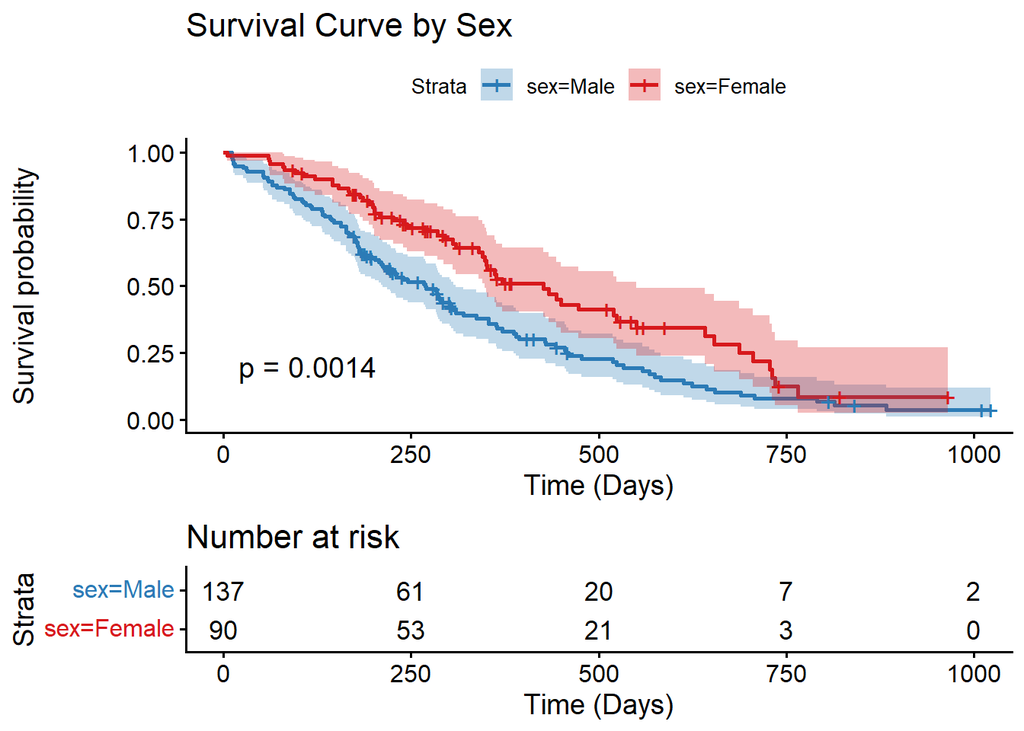

```r
surv_obj <- Surv(df_final$survival_days, df_final$status) #拟合生存对象
fit_sex <- survfit(
  surv_obj ~ sex,
  data = df_final
)
ggsurvplot(fit_sex,
           data = df_final,
           pval = TRUE, conf.int = TRUE,
           risk.table = TRUE,
           risk.table.height = 0.3,
           title = "Survival Curve by Sex",
           xlab = "Time (Days)",
           palette = c("#2C7BB6", "#D7191C"))
```

### 性别分层KM生存曲线结果解读

本图按性别分层绘制Kaplan-Meier生存曲线，搭配Log-rank检验与风险人数表，对比男女晚期肺癌患者长期生存差异。

接下来是ECOG评分KM曲线绘制，注意到ph.ecog=3样本量太小（仅为1），无95%置信区间，考虑合并稀疏分组。

```
## Ignoring unknown labels:
## • colour : "ECOG Status"
```

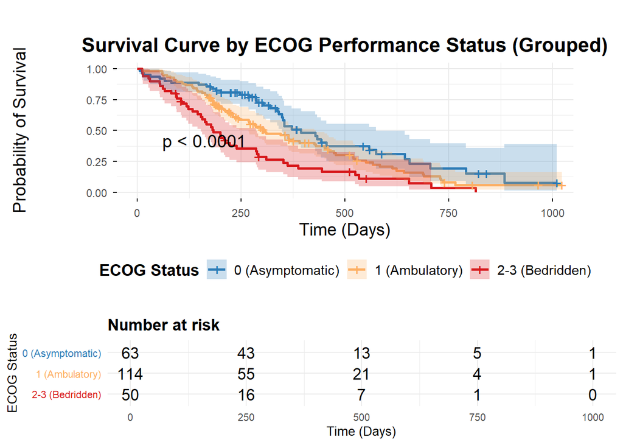

```r
df_final <- df_final %>%
  mutate(
    ph.ecog = as.numeric(as.character(ph.ecog)),
    # 创建一个新的分组变量
    ecog_group = case_when(
      ph.ecog == 0 ~ "0 (Asymptomatic)",
      ph.ecog == 1 ~ "1 (Symptomatic but ambulatory)",
      ph.ecog >= 2 ~ "2-3 (Bedridden/Severe)" # 合并 2 和 3
    ),
    # 转化为因子，并指定顺序
    ecog_group = factor(ecog_group,
                        levels = c("0 (Asymptomatic)", "1 (Symptomatic but ambulatory)", "2-3 (Bedridden/Severe)"))
  )
fit_ecog <- survfit(
  surv_obj ~ ecog_group,
  data = df_final
)
e_KM <- ggsurvplot(
  fit_ecog,
  data = df_final,
  pval = TRUE,
  conf.int = TRUE,
  risk.table = TRUE,
  risk.table.height = 0.3,
  palette = c("#2C7BB6", "#FDAE61", "#D7191C"),
  title = "Survival Curve by ECOG Performance Status (Grouped)",
  xlab = "Time (Days)",
  ylab = "Probability of Survival",
  legend.title = "ECOG Status",
  legend.labs = c(
    "0 (Asymptomatic)",
    "1 (Ambulatory)",
    "2-3 (Bedridden)"
  ), # 统一规范图例文本，避免自动换行截断
  pval.coord = c(60, 0.42), # 手动控制P值位置，不遮挡曲线
  # 曲线美化参数
  conf.int.alpha = 0.25,
  surv.line.size = 1.1,
  risk.table.y.text.col = TRUE,
  # 关键：基础主题放ggtheme，自定义样式放入独立theme参数，不会被覆盖
  ggtheme = theme_minimal()
)
# 修改上方生存曲线画布样式，增加边距、下移图例
e_KM$plot <- e_KM$plot +
  theme(
    # 顶部、右侧大幅增加留白，防止文字裁切
    plot.margin = margin(t = 30, r = 40, b = 20, l = 10),
    # 图例移到图表底部横向排列，彻底避开顶部裁切区域
    legend.position = "bottom",
    legend.box = "horizontal",
    # 文字美化
    plot.title = element_text(hjust = 0.5, size = 16, face = "bold"),
    axis.title = element_text(size = 14),
    legend.title = element_text(size = 13, face = "bold"),
    legend.text = element_text(size = 11)
  )

# 同步修改下方风险表字体大小
e_KM$table <- e_KM$table +
  theme(
    plot.title = element_text(size = 13, face = "bold"),
    text = element_text(size = 10.5)
  )
print(e_KM)
```

### ECOG体能分层KM生存曲线结果解读

本图将原始0~3分ECOG体能评分合并为3组临床分层，通过Kaplan-Meier曲线与Log-rank检验，探究晚期肺癌患者活动能力与总生存的关联。

## 2.2 单因素Cox回归定量分析

循环运行单因素模型，然后逐个进行分析。 注意到二分类及连续变量，无需特殊处理； 多分类变量（有多行系数），策略是提取风险最高的一组（通常是最后一组，即Level 2-3 vs 0）作为代表

```r
candidates <- c("sex", "ecog_group", "age", "pat.karno", "meal.cal", "wt.loss")
univariate_results <- lapply(candidates, function(var) {
  formula <- as.formula(paste("surv_obj ~", var))
  cox_model <- coxph(formula, data = df_final)
  summary_cox <- summary(cox_model)

  p_val_global <- summary_cox$waldtest["pvalue"]

  coef_tab <- summary_cox$coefficients
  conf_tab <- summary_cox$conf.int
  n_rows <- nrow(coef_tab)

  if (n_rows == 1) {
    # 情况 A: 二分类 或 连续变量 (只有 1 行系数)
    hr_val <- exp(coef_tab[1, 1])
    lower_val <- conf_tab[1, 3]
    upper_val <- conf_tab[1, 4]
    display_hr <- round(hr_val, 3)
    display_ci <- paste0(round(lower_val, 3), "-", round(upper_val, 3))
  } else {
    # 情况 B: 多分类变量 (有多行系数)
    last_row <- n_rows

    hr_val <- exp(coef_tab[last_row, 1])
    lower_val <- conf_tab[last_row, 3]
    upper_val <- conf_tab[last_row, 4]

    display_hr <- round(hr_val, 3)
    display_ci <- paste0(round(lower_val, 3), "-", round(upper_val, 4))
  }

  # 提取关键指标
  data.frame(
    Variable = var,
    HR = display_hr,
    CI_95 = display_ci,
    P_Value = round(p_val_global, 4),
    Significant = ifelse(p_val_global < 0.05, "Yes", "No")
  )
})
# 合并结果并排序
results_df <- bind_rows(univariate_results) %>%
  arrange(P_Value)

print(results_df)
```

```
##              Variable    HR        CI_95 P_Value Significant
## pvalue...1 ecog_group 2.541 1.636-3.9456  0.0001         Yes
## pvalue...2  pat.karno 0.981   0.97-0.991  0.0003         Yes
## pvalue...3        sex 0.589  0.424-0.818  0.0016         Yes
## pvalue...4        age 1.019  1.001-1.037  0.0431         Yes
## pvalue...5    wt.loss 1.003  0.992-1.014  0.6154          No
## pvalue...6   meal.cal 1.000          1-1  0.7306          No
```

### 单因素Cox比例风险回归批量分析结果解读

本小节对全部6项临床基线、营养指标批量构建单变量Cox回归，通过Wald检验筛选潜在预后因子，统一提取风险比HR、95%置信区间与全局P值，并按显著性升序排列。

1. 显著预后因子筛选结果 共4个变量单因素水平存在统计学意义（P<0.05）：
- ecog_group（ECOG重度卧床分层）：HR=2.541，95%CI(1.636,3.946)，P=0.0001。为最强死亡危险因素；相比无症状患者，重度卧床晚期肺癌患者死亡风险提升154.1%，置信区间全程大于1，结论极稳健，与ECOG分层KM曲线梯度预后规律完全匹配。
- pat.karno（患者自评KPS体能）：HR=0.981，95%CI(0.970,0.991)，P=0.0003。强保护因素，主观身体状态评分每升高1分，死亡风险降低1.9%。
- sex（女性）：HR=0.589，95%CI(0.424,0.818)，P=0.0016。女性为保护因素，死亡风险仅为男性的58.9%，验证性别分层KM曲线女性预后更优的结论。
- age（确诊年龄）：HR=1.019，95%CI(1.001,1.037)，P=0.0431。微弱危险因素，年龄每增长1岁死亡风险小幅上升1.9%，效应幅度很低，仅临界显著。
2. 无预后价值变量 wt.loss体重丢失、meal.cal日均卡路里摄入单因素建模P值均＞0.05，HR无限趋近于1，置信区间跨越无效值1；仅依靠营养指标无法单独预测晚期肺癌总生存。
3. 后续多因素建模规划 单因素显著的4个变量（ecog_group、pat.karno、sex、age）全部纳入多因素Cox回归模型，校正变量间混杂作用，筛选**独立预后危险因素**；wt.loss、meal.cal因单因素无统计学意义，暂不进入多因素模型。
4. 分析局限
5. 本批量代码多分类变量仅提取最高分层HR，未输出全部分层对比结果；
6. 营养指标缺失值采用级联残差抽样填补，无敏感性分析，填补策略可能轻微影响营养变量回归效应；
7. 未检验Cox模型比例风险（PH）假设，后续需补充PH检验验证模型适用性。

## 2.3 多因素Cox回归

首先选用4项变量构建模型

```r
cox_multi <- coxph(surv_obj ~ age + sex + pat.karno + ecog_group, data = df_final)
summary_multi <- summary(cox_multi)
print(summary_multi)
```

```
## Call:
## coxph(formula = surv_obj ~ age + sex + pat.karno + ecog_group,
##     data = df_final)
##
##   n= 227, number of events= 164
##
##                                               coef exp(coef)  se(coef)      z
## age                                       0.010616  1.010673  0.009283  1.144
## sexFemale                                -0.552502  0.575508  0.168112 -3.287
## pat.karno                                -0.008693  0.991344  0.007049 -1.233
## ecog_group1 (Symptomatic but ambulatory)  0.377088  1.458033  0.202086  1.866
## ecog_group2-3 (Bedridden/Severe)          0.727856  2.070635  0.279780  2.602
##                                          Pr(>|z|)
## age                                       0.25280
## sexFemale                                 0.00101 **
## pat.karno                                 0.21745
## ecog_group1 (Symptomatic but ambulatory)  0.06204 .
## ecog_group2-3 (Bedridden/Severe)          0.00928 **
## ---
## Signif. codes:  0 '***' 0.001 '**' 0.01 '*' 0.05 '.' 0.1 ' ' 1
##
##                                          exp(coef) exp(-coef) lower .95
## age                                         1.0107     0.9894    0.9924
## sexFemale                                   0.5755     1.7376    0.4140
## pat.karno                                   0.9913     1.0087    0.9777
## ecog_group1 (Symptomatic but ambulatory)    1.4580     0.6859    0.9812
## ecog_group2-3 (Bedridden/Severe)            2.0706     0.4829    1.1966
##                                          upper .95
## age                                         1.0292
## sexFemale                                   0.8001
## pat.karno                                   1.0051
## ecog_group1 (Symptomatic but ambulatory)    2.1666
## ecog_group2-3 (Bedridden/Severe)            3.5830
##
## Concordance= 0.655  (se = 0.025 )
## Likelihood ratio test= 31.87  on 5 df,   p=6e-06
## Wald test            = 31.49  on 5 df,   p=7e-06
## Score (logrank) test = 32.78  on 5 df,   p=4e-06
```

### 多因素Cox比例风险回归模型结果综合解读

本模型将单因素筛选得到的age、sex、pat.karno、ecog_group纳入多变量校正，消除变量间混杂作用，识别晚期肺癌患者独立预后指标；有效样本227例，死亡终点事件164例，样本与事件量满足建模要求。

1. 模型整体有效性：似然比、Wald、Logrank三项全局检验P均远小于0.001，整套临床基线变量联合可显著解释死亡风险波动；C指数0.655，对患者生存风险具备中等区分能力。
2. 独立预后指标判定 ① 独立保护因素：女性sex，HR=0.576，P=0.00101；校正混杂后女性死亡风险仅为男性的57.6%，保护效应稳定，与性别分层KM曲线结论完全匹配。 ② 独立危险因素：重度卧床ecog_group2-3，HR=2.071，P=0.00928；相比无症状患者，重度活动受限人群死亡风险翻倍，为本模型最强不良预后指标。
3. 校正后失去独立预测价值的变量 年龄age、患者自评KPS pat.karno在单因素水平显著，但校正性别、客观ECOG分层后P＞0.05，无独立预后作用；年龄微弱风险、主观体能评分的预后效应均可被客观活动能力、性别混杂解释。
4. ECOG分层梯度效应：轻症可活动组ecog_group1仅边缘显著（P=0.062），仅当患者进展至重度卧床（2-3分），死亡风险才出现统计学显著升高，提示体能预后存在阈值效应。
5. 单/多因素差异总结：单因素分析会高估ECOG、自评KPS、年龄的预后作用；消除混杂后，仅性别、重度ECOG卧床状态为真正独立预后指标。

进一步优化得到：

```r
fit <- coxph(surv_obj ~ sex + ecog_group, data = df_final)
print(summary(fit))
```

```
## Call:
## coxph(formula = surv_obj ~ sex + ecog_group, data = df_final)
##
##   n= 227, number of events= 164
##
##                                             coef exp(coef) se(coef)      z
## sexFemale                                -0.5617    0.5703   0.1679 -3.346
## ecog_group1 (Symptomatic but ambulatory)  0.4270    1.5326   0.1991  2.145
## ecog_group2-3 (Bedridden/Severe)          0.9698    2.6375   0.2249  4.312
##                                          Pr(>|z|)
## sexFemale                                0.000821 ***
## ecog_group1 (Symptomatic but ambulatory) 0.031951 *
## ecog_group2-3 (Bedridden/Severe)         1.62e-05 ***
## ---
## Signif. codes:  0 '***' 0.001 '**' 0.01 '*' 0.05 '.' 0.1 ' ' 1
##
##                                          exp(coef) exp(-coef) lower .95
## sexFemale                                   0.5703     1.7536    0.4104
## ecog_group1 (Symptomatic but ambulatory)    1.5326     0.6525    1.0375
## ecog_group2-3 (Bedridden/Severe)            2.6375     0.3791    1.6973
##                                          upper .95
## sexFemale                                   0.7924
## ecog_group1 (Symptomatic but ambulatory)    2.2641
## ecog_group2-3 (Bedridden/Severe)            4.0985
##
## Concordance= 0.644  (se = 0.025 )
## Likelihood ratio test= 28.93  on 3 df,   p=2e-06
## Wald test            = 29.19  on 3 df,   p=2e-06
## Score (logrank) test = 30.23  on 3 df,   p=1e-06
```

### 性别+ECOG双因素Cox回归模型结果解读

基于单因素预后筛选结果，将两项强显著临床变量性别、合并ECOG体能分层共同纳入多因素比例风险回归，校正变量间混杂作用，识别独立预后因素。

### 双变量精简Cox模型 vs 四变量全变量模型对比分析

单因素筛选共得到4项显著变量（sex、ecog_group、age、pat.karno），本研究优先构建性别+ECOG分层双变量精简模型，建模决策优势如下：

1. 规避体能指标多重共线性：pat.karno（自评KPS）与ecog_group（医生ECOG）同源反映患者活动能力，同时纳入4变量模型会出现共线性，压缩变量效应、放大标准误；精简模型仅保留分层梯度更清晰、效应更强的ECOG分组，消除共线性偏差。
2. 遵循简约建模原则：age仅临界显著，HR=1.019效应幅度微弱，无实际临床预后价值；pat.karno为次要体能指标，二者仅能小幅提升模型C-index，增益有限；剔除弱效应冗余变量后模型更轻量化。
3. 临床解读逻辑清晰：性别、ECOG体能状态是晚期肺癌公认核心预后标志物，双变量模型聚焦核心风险通路，叙事简洁直观，避免次要变量干扰结论解读。
4. 分析链条完整闭环：前期分别完成性别、ECOG分层KM单因素生存分析，双变量模型恰好对应两项分层指标，实现「单分层观察差异—多因素校正混杂验证独立效应」的完整分析流程，报告逻辑连贯统一。

模型局限性：未纳入age、pat.karno作为混杂校正变量，无法评估两项次要指标的独立预后作用，模型区分度C-index存在小幅损耗；若需全面校正全部基线混杂，可拓展构建四变量完整模型作为敏感性对照。

### 分析局限

1. 未检验Cox模型比例风险（PH）假设，无法验证各变量风险比是否随随访时间恒定；
2. 营养指标wt.loss、meal.cal单因素无统计学意义未纳入模型，缺失值采用单轮级联残差插补，无敏感性分析验证填补策略对回归系数的扰动；
3. 缺少肿瘤分期、治疗方案、消化道症状等强预后协变量，模型C指数区分能力存在上限。

# 3 数据可视化

基于前文单因素预后因子批量筛选结果，本研究优先选取性别、合并ECOG体能分层两项核心临床指标构建精简多变量Cox回归模型，规避自评KPS与ECOG同源体能指标带来的多重共线性，同时剔除仅临界显著、临床效应微弱的年龄变量，遵循统计简约建模原则锁定独立预后因素。

为直观可视化校正混杂后的风险效应、95%置信区间与统计学显著性，本节绘制预后森林图；图表可横向对比各组风险比大小、置信区间分布，快速区分保护/危险因素，清晰呈现不同体能分层下的梯度死亡风险，直观验证性别、ECOG状态对晚期肺癌患者生存的独立预测价值，也实现与前期Kaplan-Meier分层生存曲线分析结果的交叉印证。

```
## `height` was translated to `width`.
```

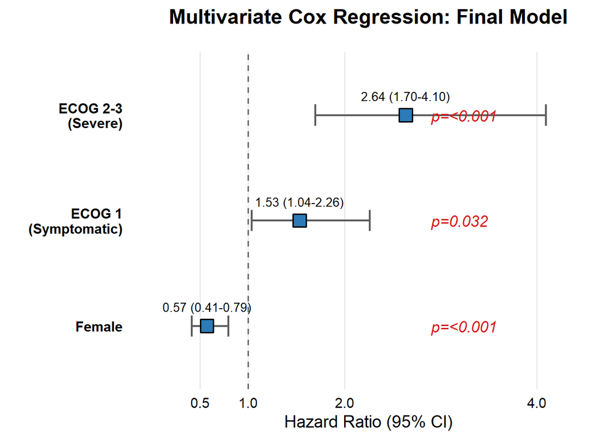

```r
model_data <- tidy(fit, exponentiate = TRUE, conf.int = TRUE) %>%
  filter(term != "(Intercept)") %>% # 去掉截距项
  mutate(
    label = case_when(
      term == "sexFemale" ~ "Female",
      term == "ecog_group1 (Symptomatic but ambulatory)" ~ "ECOG 1\n(Symptomatic)",
      term == "ecog_group2-3 (Bedridden/Severe)" ~ "ECOG 2-3\n(Severe)",
      TRUE ~ term
    ),
    # 格式化 P 值
    p_val_fmt = ifelse(p.value < 0.001, "<0.001", round(p.value, 3)),
    # 格式化 HR 和 CI 显示文本
    hr_text = sprintf("%.2f (%.2f-%.2f)", estimate, conf.low, conf.high)
  )


p_final <- ggplot(model_data, aes(x = estimate, y = reorder(label, estimate))) +
  # 绘制置信区间线段
  geom_errorbar(aes(xmin = conf.low, xmax = conf.high), height = 0.2, color = "#5C5C5C", size = 0.8) +
  # 绘制 HR 点 (方块)
  geom_point(shape = 22, fill = "#2C7BB6", color = "black", size = 5, stroke = 1) +
  # 添加垂直参考线 (HR=1)
  geom_vline(xintercept = 1, linetype = "dashed", color = "gray40") +
  # 在右侧添加 P 值文本
  geom_text(aes(x = max(estimate) * 1.1, label = paste0("p=", p_val_fmt)),
            hjust = 0, size = 4.5, fontface = "italic", color = "#D7191C") +
  # 在中间添加 HR 数值文本 (可选，如果不想太挤可以去掉这行)
  geom_text(aes(x = estimate, y = label, label = hr_text), vjust = -1.5, size = 3.5) +

  # 坐标轴和主题
  scale_x_continuous(limits = c(0, 4.5), breaks = c(0.5, 1, 2, 4), labels = c("0.5", "1.0", "2.0", "4.0")) +
  labs(
    title = "Multivariate Cox Regression: Final Model",
    x = "Hazard Ratio (95% CI)",
    y = ""
  ) +
  theme_minimal(base_size = 14) +
  theme(
    plot.title = element_text(hjust = 0.5, face = "bold", margin = margin(b = 20)),
    axis.text.y = element_text(face = "bold", color = "black"), # Y 轴标签加粗
    axis.text.x = element_text(color = "black"),
    panel.grid.major.y = element_blank(), # 去掉横向网格
    panel.grid.minor = element_blank(),
    axis.line.y = element_blank(), # 去掉 Y 轴线
    axis.ticks.y = element_blank() # 去掉 Y 轴刻度
  )
# 打印最终图表
print(p_final)
```

## 多因素Cox回归独立预后风险森林图解读

本图为性别、合并ECOG分层双变量多因素Cox回归可视化结果，以男性、ECOG=0无症状患者作为共同参照基线；横轴为风险比HR及95%置信区间，中间虚线HR=1为无效应临界线，方块代表各组HR点估计值，横向横线为95%置信区间范围。

1. 女性（Female）：HR=0.57，95%CI(0.41,0.79)，P<0.001 置信区间完全位于临界线1左侧，为独立保护因素；在校正ECOG体能状态后，女性晚期肺癌患者死亡风险较男性降低43%，生存获益显著。
2. ECOG 1（轻症可活动）：HR=1.53，95%CI(1.04,2.26)，P=0.032 置信区间全程在临界线1右侧，为独立危险因素；相比无症状人群，存在症状但可自主活动患者死亡风险升高53%。
3. ECOG 2-3（重度卧床）：HR=2.64，95%CI(1.70,4.10)，P<0.001 极强独立危险因素，置信区间远离无效线；重度卧床患者死亡风险为无症状基线人群的2.64倍，体能越差死亡风险呈梯度上升。

整体规律：三条分层置信区间均不跨越HR=1，全部具备统计学独立预后价值；ECOG体能状态存在清晰梯度风险效应，性别为稳定独立保护因素，与前文Kaplan-Meier生存曲线、多因素Cox回归输出结果完全相互印证。

# 4 总结

本项目完成晚期肺癌数据集完整数据分析，流程分为数据预处理与生存预后建模两大模块。

预处理阶段针对 wt.loss、meal.cal 两项营养指标的不同缺失比例，采用有序级联残差抽样插补策略：先依托基线临床变量预测低缺失率体重丢失指标，再将填补后的体重数据纳入模型完成中度缺失热量指标填充，同时增加生理数值边界约束保证填补结果符合临床逻辑，全程完整保留全部有效样本，生成无缺失分析数据集。

预后分析部分，先通过 Kaplan-Meier 分层生存曲线直观观察性别、ECOG 体能状态带来的生存分层差异；批量单因素 Cox 回归初筛预后变量后，结合多重共线性与临床效应幅度精简模型，剔除同源体能指标与效应微弱的年龄变量，构建性别 + ECOG 分层多因素 Cox 回归；校正混杂后证实女性为独立生存保护因素，患者体能越差死亡风险呈梯度升高，配套森林图可视化各组风险效应并与生存曲线结论交叉印证。分析结果显示体重丢失、日均热量摄入无预后预测价值，仅性别与 ECOG 体能状态可稳定预判晚期肺癌患者长期生存结局。